# Question

Angenommen **vier Forscher:innen-Teams** untersuchen jeweils die Wirksamkeit von formativem Assessment in einem randomisiert kontrollierten Experiment. Welche Aussagen bzgl. Effektstärke und Inferenzstatistik passen zu welchem Ergebnis angenommen die Nullhypothese lautet $MW_\text{Formatives Assessment} = MW_\text{Kontrollgruppe}$ und die Alternativhypothese $MW_\text{Formatives Assessment} > MW_\text{Kontrollgruppe}$?

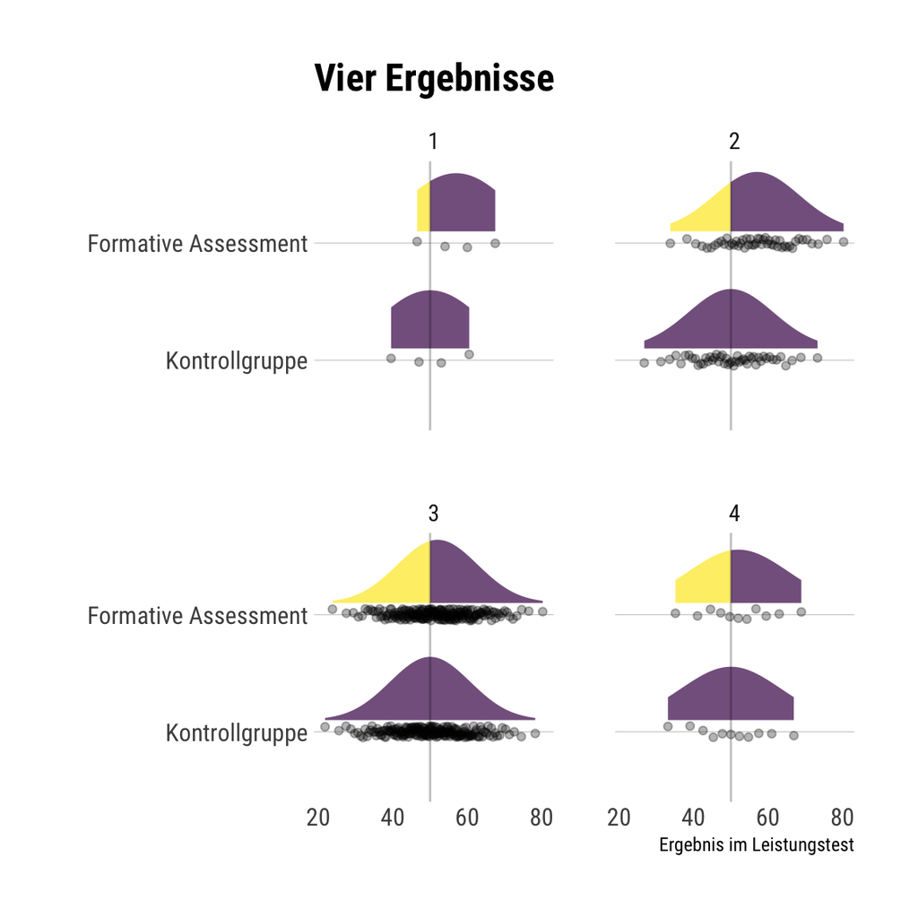

## Answerlist

- 1 = Starker Effekt & Große Unsicherheit, 2 = Starker Effekt & Geringe Unsicherheit, 3 = Schwacher Effekt & Geringe Unsicherheit, 4 = Schwacher Effekt & Große Unsicherheit.
- 1 = Starker Effekt & Geringe Unsicherheit, 2 = Schwacher Effekt & Geringe Unsicherheit, 3 = Schwacher Effekt & Große Unsicherheit, 4 = Starker Effekt & Große Unsicherheit.
- 1 = Schwacher Effekt & Geringe Unsicherheit, 2 = Schwacher Effekt & Große Unsicherheit, 3 = Starker Effekt & Große Unsicherheit, 4 = Starker Effekt & Geringe Unsicherheit.
- 1 = Schwacher Effekt & Große Unsicherheit, 2 = Starker Effekt & Große Unsicherheit, 3 = Starker Effekt & Geringe Unsicherheit, 4 = Schwacher Effekt & Geringe Unsicherheit.
- 1 = Starker Effekt & Geringe Unsicherheit, 2 = Schwacher Effekt & Große Unsicherheit, 3 = Starker Effekt & Große Unsicherheit, 4 = Schwacher Effekt & Geringe Unsicherheit.
- 1 = Schwacher Effekt & Große Unsicherheit, 2 = Schwacher Effekt & Geringe Unsicherheit, 3 = Starker Effekt & Geringe Unsicherheit, 4 = Starker Effekt & Große Unsicherheit.

# Meta-information

exname: hoheniedrige_sicherheiteffekstaerke_inabberkennen extype: schoice exsolution: 100000 exshuffle: true